# **Project Assessment 1: Reproducible Research**

Charmaine Hough

20th December 2015

## Set the markdown file to show all code and output

```r
library(knitr)
opts_chunk$set(echo = TRUE)
```

## Set working directory

### Note to user: set this to your own working directory which contains the file activity.csv

```r
setwd("C:\\Users\\ctam0304.MCS\\Desktop\\datasciencecoursera\\5.ReproducibleResearch\\PeerAssessment1")
```

## Load in the necessary packages

```r
library(tidyr)
library(dplyr)
```

```r
library(ggplot2)
```

## Loading and preprocessing the data

```r
activity <- read.csv("activity.csv",header=TRUE)
activity$date <- as.Date(activity$date,format="%Y-%m-%d")
activity$steps <- as.numeric(activity$steps)
activity$interval <- as.numeric(activity$interval)
```

## What is the mean total number of steps taken per day?

### 1. Calculate the total number of steps taken per day

```r
activity %>% group_by(date) %>% summarise(sum= sum(steps)) -> totalsteps
```

### 2. Make a histogram of the total number of steps taken each day

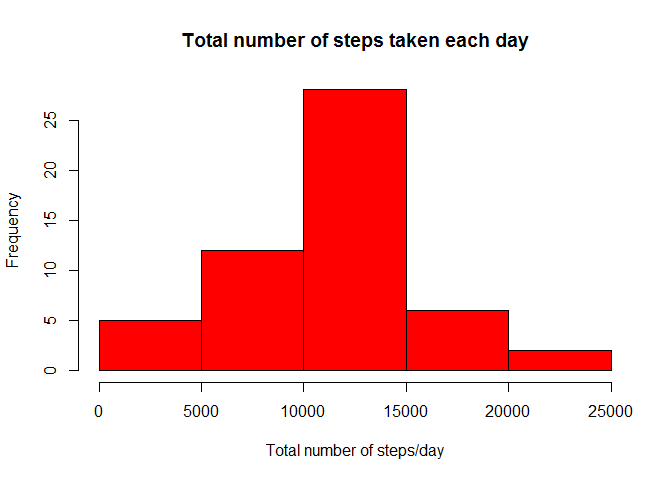

```r
hist(totalsteps$sum,
     main= paste("Total number of steps taken each day"),
     xlab = "Total number of steps/day",
     col="red")
```

### 3. Calculate and report the mean and median of the total number of steps taken per day

```r
totalsteps %>%
  summarise(avg=round(mean(sum,na.rm=TRUE)),
            median=median(sum, na.rm=TRUE))
```

```
## Source: local data frame [1 x 2]
##
##     avg median
##   (dbl)  (dbl)
## 1 10766  10765
```

## What is the average daily activity pattern?

### 1. Make a time series plot of the 5-minute interval and the average number of steps taken, averaged across all days

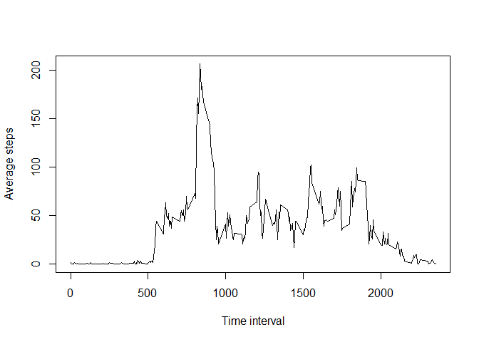

```r
activity %>% group_by(interval) %>% summarise(avg=round(mean(steps,na.rm=TRUE))) ->meansteps

plot(meansteps$interval,meansteps$avg,
     type="l",
     col="black",
     xlab="Time interval",
     ylab="Average steps")
```

### 2. Calculate which 5-minute interval, on average across all the days in the dataset, contains the maximum number of steps

```r
summarise(meansteps,maximum=max(avg))
```

```
## Source: local data frame [1 x 1]
##
##   maximum
##     (dbl)
## 1     206
```

```r
which(meansteps$avg=="206") ->ind
meansteps[ind,]
```

```
## Source: local data frame [1 x 2]
##
##   interval   avg
##      (dbl) (dbl)
## 1      835   206
```

#### The interval with the maximum number of steps is 835

## Imputing missing values

### 1. Calculate and report the total number of missing values in the dataset

```r
activity %>% filter(is.na(steps)) %>% count()
```

```
## Source: local data frame [1 x 1]
##
##       n
##   (int)
## 1  2304
```

### 2. Devise a strategy for filling in all of the missing values in the dataset

```r
activity_complete <- activity
nas <- is.na(activity_complete$steps)
avg_interval <- tapply(activity_complete$steps,
                       activity_complete$interval,
                       mean,
                       na.rm=TRUE,
                       simplify=TRUE)
avg_interval <- round(avg_interval,digits=0)
activity_complete$steps[nas] <- avg_interval[as.character(activity_complete$interval[nas])]
```

### 3. Checking that there are no more nas

```r
sum(is.na(activity_complete$steps))
```

```
## [1] 0
```

### 4.Make a histogram of the total number of steps taken each day

[figure not shown]

```r
activity_complete %>% group_by(date) %>% summarise(sum= sum(steps)) -> completetotalsteps

hist(totalsteps$sum,
     main= paste("Total number of steps taken each day including missing data"),
     xlab = "Total number of steps/day",
     col="red")
```

### 5. Calculate and report the mean and median total number of steps taken per day

```r
completetotalsteps %>%
  summarise(avg=round(mean(sum,na.rm=TRUE)),
            median=median(sum, na.rm=TRUE))
```

```
## Source: local data frame [1 x 2]
##
##     avg median
##   (dbl)  (dbl)
## 1 10766  10762
```

## Are there differences in activity patterns between weekdays and weekends?

### 1. First, create a new factor variable in the dataset with two levels - “weekday” and “weekend”

```r
activity_complete <- mutate(activity_complete,
                            weektype =
                              ifelse(weekdays(activity_complete$date) == "Saturday" |                               weekdays(activity_complete$date) == "Sunday",
                                "weekend", "weekday"))
activity_complete$weektype <- as.factor(activity_complete$weektype)
```

### 2. Work out average total number of steps for weekdays or weekends

```r
activity_complete %>% group_by(interval,weektype) %>%
summarise(avg=round(mean(steps,na.rm=TRUE))) ->meansteps_weektype
```

### 3. Make a panel plot containing a time series plot of the 5-minute interval and the average number of steps taken, averaged across all weekday days or weekend days

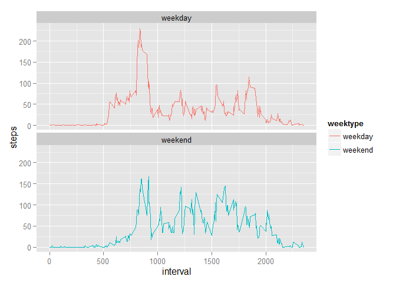

```r
plot <- ggplot(meansteps_weektype, aes(x=interval, y=avg, colour=weektype)) +
        geom_line() +
        facet_wrap(~weektype, ncol = 1, nrow=2) +
        ylab("steps")

print(plot)
```